# article

**Stored grain protection: Bibliometric trends and a narrative synthesis of monitoring and storage technologies**

Wagner Meza-Maicelo1,2,4, Victor-Hugo Baldera-Chapoñan1,2,4, Damaris Leiva-Tafur3,4, Manuel Oliva-Cruz1,4 and Flavio Lozano-Isla1,2,3,*

1Facultad de Ingeniería y Ciencias Agrarias, Universidad Nacional Toribio Rodríguez de Mendoza de Amazonas (UNTRM-A), Chachapoyas 01001, Perú.

2Centro de Investigación e Innovación en Granos y Semillas (CEIGRAS), Universidad Nacional Toribio Rodríguez de Mendoza de Amazonas (UNTRM-A), Chachapoyas 01001, Perú.

3 Escuela de Posgrado, Programa Doctoral en Ciencias para el Desarrollo Sustentable, Facultad de Ingeniería Zootecnista, Biotecnología, Agronegocios y Ciencia de Datos, Universidad Nacional Toribio Rodríguez de Mendoza de Amazonas (UNTRM-A), Chachapoyas 01001, Perú.

4 Instituto de Investigación para el Desarrollo Sustentable de Ceja de Selva (INDES CES), Facultad de Ingeniería y Ciencias Agrarias, Universidad Nacional Toribio Rodríguez de Mendoza de Amazonas (UNTRM-A), Chachapoyas 01000, Perú.

*Corresponding author: Flavio Lozano-Isla <flavio.lozano@untrm.edu.pe>

**Highlights**

- Scientific production on stored grains has grown steadily since 2018.
- Trogoderma granarium emerges as a driving topic due to its resistance to fumigants.
- Research is shifting from fumigants toward biological control and essential oils.
- Nanopesticides represent the most recent technological frontier in the field.
- Adoption of hermetic technologies remains limited by economic factors and training constraints.

**Abstract**

**Keywords:** biocontrol, pests, postharvest, monitoring, nanopesticides, repellency.

# 1 **1. Introduction**

Grains (harvested seeds) are composed of the bran, germ, and endosperm [(Van Der Kamp et al., 2014)](https://www.zotero.org/google-docs/?zwv9qN) and are generally stored in granaries prior to processing and/or consumption [(Jian, 2025)](https://www.zotero.org/google-docs/?AQqCL8). Among the economically important grains are maize, wheat, and rice, which account for 90% of cereal production worldwide [(Yamini et al., 2025)](https://www.zotero.org/google-docs/?V6IMdF). These grains play a fundamental role in human nutrition, contributing to food security [(Erenstein et al., 2022; Fukagawa & Ziska, 2019; Shiferaw et al., 2013)](https://www.zotero.org/google-docs/?rzGEpc), , in the context of sustained demographic growth — global population is estimated to reach 8.5 billion by 2030 and 9.7 billion by 2050 — making sufficient food production essential to achieving Sustainable Development Goal 2: Zero Hunger [(Feeding the Future Global Population, 2024)](https://www.zotero.org/google-docs/?AkJudr).

Grain storage is adversely affected by pests, diseases, and inadequate storage practices [(Fleurat-Lessard, 2017; Forbanka, 2021)](https://www.zotero.org/google-docs/?V3qBGj). The most common pests include the rice weevil (*Sitophilus oryzae*), the red flour beetle (*Tribolium castaneum*), the lesser grain borer (*Rhyzopertha dominica*), and the khapra beetle (*Trogoderma granarium*) [(Srivastava & Subramanian, 2016)](https://www.zotero.org/google-docs/?kcnOh4). These insects not only feed on the grain but also contaminate it with their excreta, thereby reducing its quality [(Mutalov et al., 2025)](https://www.zotero.org/google-docs/?1ej1pi). The most prevalent diseases involve *Penicillium* spp., *Aspergillus* spp., *Alternaria* spp., *Fusarium* spp., and *Rhizopus stolonifera*, whose presence causes discoloration, musty odor, dry matter loss, tissue decomposition, and mycotoxin accumulation, ultimately degrading the nutritional and processing quality of the grain through processes influenced by temperature and humidity [(Mannaa & Kim, 2017)](https://www.zotero.org/google-docs/?J3ixuK). Common poor storage practices include storing grain at high moisture content, inadequate temperature control, insufficient warehouse sanitation, the presence of impurities, and poor ventilation [(Ziegler et al., 2021)](https://www.zotero.org/google-docs/?UpRdvU).

Multiple approaches have been evaluated for grain protection during storage, including biological methods (parasitoids, predators, entomopathogens, antagonists, and bacteria) [(Boukaew et al., 2024; del Arco et al., 2023; Roberto Gonc¸alves et al., 2004; Wakil et al., 2014; Wang et al., 2024)](https://www.zotero.org/google-docs/?c4RYmh), botanical methods (plant extracts and essential oils) [(Mota Filho et al., 2024; Seepe et al., 2020)](https://www.zotero.org/google-docs/?zRJGnX), and synthetic insecticides (organophosphates, carbamates, neonicotinoids, and insect growth regulators) (Denloye et al., 2007; Elek, 1998; Nayak et al., 2003; Yue et al., 2003). Physical and environmental management methods have also been employed, including controlled atmosphere, grain cooling, ozonation, irradiation, and electromagnetic wave treatments [(Calderon & Navarro, 1980; Keszthelyi et al., 2021; Longstaff, 1988; Rucins et al., 2021)](https://www.zotero.org/google-docs/?eHBPJi). Additionally, storage systems such as hermetic bags, metal silos, and polypropylene-reinforced jute sacks have been incorporated [(Dubey et al., 2026; Odjo et al., 2022)](https://www.zotero.org/google-docs/?ehne9b), alongside pest monitoring and exclusion strategies using water traps and insecticide-impregnated nets [(Ranabhat et al., 2025; Waiters & Cox, 1957)](https://www.zotero.org/google-docs/?aSQAb7).

From a global perspective, research groups across numerous countries have contributed to the study of stored grain protection. Their findings, disseminated through scientific journals and academic databases, have consolidated the body of knowledge available in this field. In this context, bibliometric analysis emerges as a quantitative method that enables the study of scientific literature in a more objective and systematic manner than narrative reviews [(Donthu et al., 2021)](https://www.zotero.org/google-docs/?JZGfh3). The present article adopts a bibliometric approach focused on stored grain protection techniques, while also incorporating a narrative section that synthesizes the scientific knowledge, thereby allowing the identification of research trends and gaps — aspects that would not be apparent through a purely bibliometric analysis. The insights obtained are expected to advance the scientific agenda on stored grain protection and to strengthen strategies aimed at global food security.

The specific objectives of this study were: (i) to analyze the trends, collaboration networks, and thematic evolution of the field, and (ii) to synthesize, from the bibliometric corpus, the main strategies for detection, trapping, packaging, and protection of grain storage environments.

**2. Materials and Methods**

**2.1. Metadata extraction and processing**

The review was conducted following the PRISMA (Preferred Reporting Items for Systematic Reviews and Meta-Analyses) guidelines [(Page et al., 2021; Sarkis-Onofre et al., 2021)](https://www.zotero.org/google-docs/?noBErM) (Figure 1).

[figure not shown]

Figure 1. PRISMA flow diagram illustrating the process of metadata processing for bibliometric analysis.

Scopus was selected for its broad coverage of peer-reviewed journals, its standardized metadata, and its widespread use in bibliometric analyses (Falagas et al., 2008; Singh et al., 2021). The comprehensive search was conducted on May 20, 2026, at 10:36 UTC−5, using the query TITLE-ABS-KEY(“postharvest grain storage” OR “stored grain” OR “grain preservation”), which yielded 3,609 results (Figure 1 A). Within the results interface, no year range was defined; however, subject areas were restricted to Agricultural and Biological Sciences, Environmental Sciences, and Engineering, reducing the results to 3,023 documents. Review-type studies were then excluded, leaving 2,863 documents, with no language restriction applied. Records containing the keywords “article” and “nonhuman” were also removed, reducing the total to 2,605 documents (Figure 1 B). All remaining fields were left unmodified, and the results were prepared for independent title and abstract screening by three researchers. Disagreements arising during this stage were resolved through joint discussion until consensus was reached among all three researchers.

Following title and abstract screening within the Scopus interface, studies meeting the following inclusion criteria were retained:

1. The study addressed postharvest grain storage, excluding research related to production or pre-harvest stages.
2. The study evaluated damage caused by pests, diseases, or physical and/or chemical deterioration processes in stored grains.
3. The study analyzed methods for the prevention, management, or control of damage in stored grains, including physical, chemical, biological, environmental, or combined strategies.
4. The study presented technical or experimental information related to grain storage, such as treatments, inputs, storage conditions, mechanisms of action, pest behavior, application techniques, or laboratory assessments.

Subsequently, at 23:19 UTC−5 on the same day, 1,043 records meeting the inclusion criteria were identified (Figure 1 C) and exported from Scopus in comma-separated values (.csv) format, including citation information, bibliographic data, abstracts, keywords, and funding details (Figure 1 D). Four duplicate records were then removed based on title matching and 142 based on Digital Object Identifier (DOI) matching (Figure 1 E), yielding a final dataset of 897 records, which were used in the bibliometric analysis (Figure 1 F).

**2.2. Bibliometric analysis**

The bibliometric analysis was performed using the Bibliometrix package v. 5.4.1 [(Aria & Cuccurullo, 2016)](https://www.zotero.org/google-docs/?A3TKVm), executed in R v. 4.5.1 [(R Core Team, 2025)](https://www.zotero.org/google-docs/?olVwEF) through its graphical user interface Biblioshiny. Productivity and scientific impact indicators (total citations, and h-, g-, and m-indices) were calculated at the country, author, and journal levels. The temporal trend of publications and citations was modeled using second-degree polynomial (quadratic) regression, with goodness of fit assessed through the coefficient of determination (R²); the Pearson correlation coefficient between annual publication counts and citation counts was also estimated. International collaboration networks, researcher co-authorship networks, and author co-citation networks were constructed and visualized using VOSviewer v. 1.6.20 [(van Eck & Waltman, 2023)](https://www.zotero.org/google-docs/?QqZjJO), applying a minimum threshold of five collaborations per node. The keyword analysis included the construction of a term frequency cloud, a thematic trend map, a thematic evolution diagram divided into four time periods, and a thematic map based on the centrality and density indicators proposed by [(Callon et al., 1991)](https://www.zotero.org/google-docs/?lfjZKv), classifying concepts as basic, motor, niche, and emerging/declining themes. Quantitative outputs were exported from Biblioshiny in spreadsheet format (.xlsx) and further processed in R for table preparation.

**2.3. Narrative synthesis**

From the bibliometric corpus of 897 documents, the authors identified a subset specifically addressing strategies for the detection, trapping, packaging, and protection of grain storage environments — a topic considered of particular relevance and interest to readers, as it synthesizes the technological advances in this field. During the screening of titles, abstracts, and, when necessary, full texts, articles providing technical or experimental evidence on these methods were systematically separated and used as the basis for constructing the narrative synthesis.

**3. Results and discussion**

**3.1. Trends, collaboration networks, and thematic evolution**

**3.1.1. Analysis of global scientific production**

To characterize the volume, nature, and temporal evolution of scientific production on stored grain protection, the distribution of documents was analyzed according to document type and publication and citation trends over the study period.

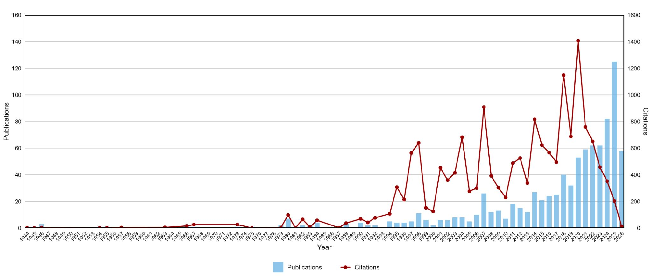

Figure 2. Annual trends in scientific production (light blue bars, left axis) and annual citations (red line, right axis) on stored grain protection from 1944 to mid-2026.

The sustained increase observed since 2018, and particularly the peak recorded in 2025, may be partly explained by the re-emergence of *Trogoderma granarium* (khapra beetle) as a quarantine pest of international significance. As detailed in Section 3.1.4, this term exhibits one of the highest recent growth rates and is positioned as a motor theme within the field, suggesting that its resistance to conventional fumigants may have stimulated increased research funding. Similarly, the incorporation of emerging approaches such as nanopesticides — also identified in that section — may have contributed to this resurgence, given that frontier technologies tend to generate rapid waves of exploratory publications. It should be noted that, as of May 20, 2026 (the data extraction date), 58 publications had already been recorded for the current year; should this pace be maintained, the 2026 output could surpass that of 2025, further reinforcing the field’s growth trajectory.

**3.1.2. Distribution of scientific production and collaboration networks**

To identify the main actors who have contributed to the development of the field and to understand the collaboration patterns underpinning scientific production, the distribution of publications by country, institution, author, and source was analyzed, along with co-authorship networks at both the international and individual levels.

Of the ten countries with the highest scientific output (57–254 publications), five recorded more than 150 publications, with three Asian countries standing out — India (254), Pakistan (239), and China (229) — along with two countries from the Americas: Brazil (240) and the United States (176). Among the most productive affiliations were the University of Agriculture, Pakistan (45), Henan University of Technology, China (26), Universidade Federal de Viçosa, Brazil (22), and Purdue University, United States (21). This suggests that, in some countries, scientific production may be concentrated in a small number of highly productive institutions, whereas in others it may be distributed across a larger number of affiliations. Among the most productive authors were Athanassiou, Christos G. (38), Professor at the University of Thessaly, Greece ([Loop profile: 166327](http://loop.frontiersin.org/people/166327/overview?referrer=orcid_profile) ), and Kavallieratos, Nickolas G. (25), Professor at the Agricultural University of Athens, Greece ([Loop profile: 298520](http://loop.frontiersin.org/people/298520/overview?referrer=orcid_profile)), whose research lines focus on stored grains, insecticide resistance, and control strategies. The high productivity of these researchers may help explain Greece’s position as the sixth most productive country (93 publications), indicating that in some countries scientific output may be concentrated among a small number of highly prolific authors. Among the most productive sources, there was a marked difference between the leading journal, the *Journal of Stored Products Research* (172 publications), and the second, *Crop Protection* (29 publications). This gap may be attributed to the more specialized focus of the former on stored grains, insects, and conservation strategies — the central themes of this bibliometric study (Table 1).

Table 1. Leading countries, institutions, authors, and journals in research on stored grain protection techniques.

| Rank | Country | Records | Affiliation | Records | Author | Records | Records Fractionalized | Source (Q) | Records |
| --- | --- | --- | --- | --- | --- | --- | --- | --- | --- |
| 1 | India | 254 | University of Agriculture | 45 | Athanassiou, Christos G. | 38 | 11.39 | Journal of Stored Products Research (Q1) | 172 |
| 2 | Brazil | 240 | Henan University of Technology | 26 | Kavallieratos, Nickolas G. | 25 | 5.83 | Crop Protection (Q1) | 29 |
| 3 | Pakistan | 239 | Universidade Federal de Viçosa | 22 | Wakil, Waqas | 14 | 2.92 | International Journal of Tropical Insect Science (Q3) | 24 |
| 4 | China | 229 | Purdue University | 21 | Faroni, Leda Rita D’A. | 11 | 2.55 | Journal of Economic Entomology (Q1) | 20 |
| 5 | USA | 176 | Kansas State University | 19 | Fields, P. G. | 10 | 3.84 | Insects (Q1) | 17 |
| 6 | Greece | 93 | Agricultural University of Athens | 18 | Arthur, Frank H. | 9 | 3.48 | Journal of Pest Science (Q1) | 14 |
| 7 | Egypt | 87 | University of Pisa | 18 | Nayak, Manoj K. | 9 | 2.65 | Journal of Plant Diseases and Protection (Q1) | 13 |
| 8 | Australia | 63 | University of the Punjab | 18 | Obeng-Ofori, Daniel | 9 | 3.07 | Pest Management Science (Q1) | 13 |
| 9 | Turkey | 62 | King Saud University | 17 | Rajashekar, Yallappa | 8 | 2.63 | Journal of the Chinese Cereals and Oils Association (Q4) | 11 |
| 10 | Saudi Arabia | 57 | Plant Protection Research Institute | 13 | Sagheer, Muhammad | 8 | 1.49 | Environmental Science and Pollution Research (Q1) | 10 |

∗ Source: Authors’ own elaboration based on data exported from Scopus.

The international co-authorship network (>5 collaborations; Figure 3) identified four country clusters. The first cluster, led by India, China, Pakistan, and the United States, exhibited the highest collaboration density and integrated countries from Asia, Europe, Africa, and Oceania, occupying a central position within the network. The second cluster, led by Brazil, brought together primarily Latin American countries along with collaborators from Africa, Asia, and Europe, evidencing broad intercontinental interaction. The third cluster, headed by Saudi Arabia, included Egypt, Canada, and Morocco, positioning itself among the main collaboration groups. Finally, the fourth cluster, led by Germany, grouped European and African countries with close co-authorship ties. These linkages suggest that shared challenges in grain conservation act as a key driver in the formation of international research networks.

[figure not shown]

Single-country publication (SCP) and multi-country publication (MCP) trends (Figure 4) help explain the co-authorship networks. The output of Mexico, Turkey, India, and Iraq is predominantly domestic (>90% SCP), suggesting a high degree of intranational collaboration. The output of Greece, Italy, and Algeria is balanced (approximately 50% SCP and MCP). In contrast, Chile’s output is predominantly international (>80% MCP). This is consistent with the observation that larger research teams tend to be more diverse and exhibit greater interinstitutional and international collaboration [(Gazni et al., 2012)](https://www.zotero.org/google-docs/?5S6AAD).

[figure not shown]

Figure 4. Distribution of publications according to the corresponding author’s country, distinguishing between those with exclusively domestic participation (SCP) and those involving international collaboration (MCP).

The co-authorship networks (>5 collaborations; Figure 5) identified three author clusters with distinct research lines. The first cluster, articulated around Athanassiou, Christos G., and comprising Vassilakos, Thomas N., Lampiri, Evagelia, and Morrison, William R., focuses on the ecology and monitoring of postharvest pests, including studies on diversity, seasonal dynamics, spatial distribution, and the evaluation of capture traps [(Agrafioti et al., 2024; Bohinc et al., 2025; Katranas et al., 2024; Lampiri et al., 2025)](https://www.zotero.org/google-docs/?CDLjH3). The second cluster, led by Kavallieratos, Nickolas G., and composed of Wakil, Waqas, Rasool, Khawaja G., Aldawood, Abdulrahman S., Husain, Mureed, and Eleftheriadou, Nikoleta, addresses integrated pest management through entomopathogenic fungi such as *Beauveria bassiana* and *Metarhizium robertsii*, entomopathogenic nematodes, diatomaceous earth, and their combination with insecticides [(Alwaneen et al., 2024; Wakil et al., 2023, 2024)](https://www.zotero.org/google-docs/?HJW3dk). The third cluster, structured around Arthur, Frank H., together with Phillips, Thomas W., Maier, Dirk E., and Nayak, Manoj K., concentrates its research on stored grain protection through the detection and management of phosphine resistance in economically important insect pests [(Afful et al., 2021; Cato et al., 2019; Daglish et al., 2018)](https://www.zotero.org/google-docs/?96h6eL).

[figure not shown]

Figure 5. Co-authorship network among the leading researchers in stored grain protection. Nodes represent authors and their size is proportional to the number of publications, while links reflect the frequency of collaboration among them.

The three-field plot illustrates the relationships among authors (AU), country of affiliation (AU_CO), and publication sources (SO; Figure 6). Authors such as Athanassiou, Christos G., Kavallieratos, Nickolas G., and Wakil, Waqas are associated with multiple countries and publication sources, suggesting their role as “bridge researchers” — that is, authors who connect different communities within the collaboration network [(Long et al., 2013)](https://www.zotero.org/google-docs/?SrcGr3).

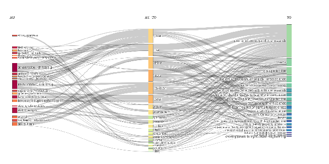

Figure 6. Three-field plot relating authors (AU), country of affiliation (AU_CO), and publication sources (SO). Rectangle size indicates the relative productivity of each node, and line thickness represents the number of documents in which collaboration has occurred between the linked categories.

**3.1.3. Citation analysis**

To evaluate the scientific impact of the main actors previously identified, the cumulative number of citations by country, author, and journal was examined, complemented by the h-, g-, and m-indices, which allow the simultaneous assessment of the productivity and influence of each actor within the field.

Table 2*.* Leading countries, authors, and journals with the greatest scientific impact in research on stored grain protection techniques.

| Rank | Country | TC | Author | h-index | g-index | m-index | TC | PY_start | Source | h-index | g-index | m-index | TC | PY_start |
| --- | --- | --- | --- | --- | --- | --- | --- | --- | --- | --- | --- | --- | --- | --- |
| 1 | USA | 1540 | Athanassiou Christos G. | 20 | 34 | 0.83 | 1207 | 2003 | Journal of Stored Products Research | 39 | 64 | 0.64 | 4724 | 1966 |
| 2 | Brazil | 1363 | Kavallieratos Nickolas G. | 16 | 25 | 0.67 | 957 | 2003 | Crop Protection | 18 | 29 | 0.51 | 1245 | 1992 |
| 3 | India | 1270 | Wakil Waqas | 10 | 14 | 0.63 | 304 | 2011 | Insects | 13 | 17 | 1.18 | 485 | 2016 |
| 4 | Greece | 1233 | Fields P.G. | 9 | 10 | 0.28 | 440 | 1995 | Journal of Economic Entomology | 13 | 20 | 0.16 | 744 | 1946 |
| 5 | China | 897 | Arthur Frank H. | 8 | 9 | 0.29 | 360 | 1999 | Journal of Pest Science | 11 | 14 | 0.65 | 538 | 2010 |
| 6 | Australia | 774 | Nayak Manoj K. | 8 | 9 | 0.28 | 536 | 1998 | International Journal of Tropical Insect Science | 10 | 17 | 0.45 | 307 | 2005 |
| 7 | Canada | 593 | Obeng-Ofori Daniel | 8 | 9 | 0.25 | 281 | 1995 | Pest Management Science | 10 | 13 | 0.67 | 298 | 2012 |
| 8 | Pakistan | 573 | Korunic Z. | 7 | 7 | 0.23 | 398 | 1996 | Environmental Science and Pollution Research | 8 | 10 | 0.80 | 374 | 2017 |
| 9 | Italy | 528 | Rajashekar Yallappa | 7 | 8 | 0.50 | 177 | 2013 | Industrial Crops and Products | 8 | 10 | 0.47 | 536 | 2010 |
| 10 | Argentina | 485 | Sagheer Muhammad | 7 | 8 | 0.64 | 74 | 2016 | International Journal of Pest Management | 8 | 10 | 0.26 | 337 | 1996 |

∗ Source: Authors’ own elaboration based on data exported from Scopus.

Table 3. Top ten most-cited publications on stored grain protection.

| Rank | Title | Author | Source | TC | Document |
| --- | --- | --- | --- | --- | --- |
| 1 | Plant oils as fumigants and contact insecticides for the control of stored-product insects | [(Shaaya et al., 1997)](https://www.zotero.org/google-docs/?DOnyWz) | Journal of Stored Products Research | 443 | Article |
| 2 | Fumigant toxicity of essential oils from the Myrtaceae family and 1,8-cineole against 3 major stored-grain insects | [(Lee et al., 2004)](https://www.zotero.org/google-docs/?eYr956) | Journal of Stored Products Research | 285 | Article |
| 3 | Fumigant toxicity of essential oils and their constituent compounds towards the rice weevil, *Sitophilus oryzae* (L.) | [(Lee et al., 2001)](https://www.zotero.org/google-docs/?FEJKIJ) | Crop Protection | 284 | Article |
| 4 | Antifungal Activity of Oregano and Thyme Essential Oils Applied as Fumigants Against Fungi Attacking Stored Grain | [(Paster et al., 1995)](https://www.zotero.org/google-docs/?WaZ39Q) | Journal of Food Protection | 213 | Article |
| 5 | Insecticidal activity of monoterpenes against *Rhyzopertha dominica* (F.) and *Tribolium castaneum* (Herbst) | [(Prates et al., 1998)](https://www.zotero.org/google-docs/?tEM701) | Journal of Stored Products Research | 213 | Article |
| 6 | *Pimpinella anisum* essential oil nanoemulsions against *Tribolium castaneum*-insecticidal activity and mode of action | [(Hashem et al., 2018)](https://www.zotero.org/google-docs/?0R1PHA) | Environmental Science and Pollution Research | 209 | Article |
| 7 | Penetration of ozone into columns of stored grains and effects on chemical composition and processing performance | [(Mendez et al., 2003)](https://www.zotero.org/google-docs/?zU2QWS) | Journal of Stored Products Research | 201 | Article |
| 8 | Trichogramma in Brazil: feasibility of use after twenty years of research | [(Parra & Zucchi, 2004)](https://www.zotero.org/google-docs/?7gDHEK) | Neotropical Entomology | 147 | Article |
| 9 | The effect of diatomaceous earth on grain quality | [(Korunic et al., 1996)](https://www.zotero.org/google-docs/?UHazl2) | Postharvest Biology and Technology | 147 | Article |
| 10 | Effectiveness of spinosad as a grain protectant against resistant beetle and psocid pests of stored grain in Australia | [(Nayak et al., 2005)](https://www.zotero.org/google-docs/?2BnG23) | Journal of Stored Products Research | 145 | Article |

∗ Source: Authors’ own elaboration based on data exported from Scopus.

Figure 7 shows the author co-citation network, comprising three clusters. The green cluster was led by Arthur, F.H., Athanassiou, C.G., Korunic, Z., and Throne, J.E.; the blue cluster by Nayak, M.K., Phillips, T.W., and Collins, P.J.; while the red cluster was headed by Isman, M.B. The high co-citation frequency of these authors indicates that their works are recurrently cited together, establishing them as key references in the field of grain conservation. The formation of these clusters suggests that the authors have made contributions within related research lines, such that their studies tend to be cited jointly in works addressing similar topics.

[figure not shown]

Figure 7. Author co-citation network in research on stored grain protection. Node size indicates the co-citation frequency of each author, while link thickness represents the strength of the co-citation relationship between pairs of authors. Colors identify clusters of authors with similar citation patterns, and the proximity between nodes reflects a greater degree of intellectual association within the field of study.

**3.1.4. Keyword analysis**

To analyze the conceptual structure of research on grain conservation techniques, author keywords were used to identify the most frequent terms, determine the thematic trends of greatest interest in recent years, evaluate the evolution of research lines across different periods, and construct a conceptual map classifying topics as basic, motor, niche, and emerging or declining themes.

The keyword cloud (Figure 8) reveals the predominance of pest species, including *Tribolium castaneum* (98 occurrences), *Sitophilus oryzae* (67), *Rhyzopertha dominica* (47), and *Sitophilus zeamais* (33). This reflects the economic importance of these beetles as the primary pests in storage systems. The high recurrence of *T. castaneum* is consistent with its adaptability and resistance to multiple control strategies, which makes it a model organism in toxicology studies [(Edwards et al., 1991; Shawir et al., 1988)](https://www.zotero.org/google-docs/?4fypmO). The presence of terms such as “mortality” (40), “toxicity” (40), and “repellency” (33) reflects the evaluation of both synthetic and natural control strategies. Particularly noteworthy is the appearance of “diatomaceous earth” (36), “essential oils” (35), and “biological control” (30), indicating a growing orientation toward integrated management approaches that prioritize physical, botanical, and biological alternatives over conventional insecticides [(Flinn & Hagstrum, 2001; Korunic et al., 1996; Paster et al., 1995)](https://www.zotero.org/google-docs/?5Mae3p). The presence of “phosphine” and “fumigation” reflects the historical and current importance of these methods, albeit with a tendency to be complemented or replaced by strategies with lower environmental impact [(Hocking & Banks, 1991)](https://www.zotero.org/google-docs/?5FgAnx).

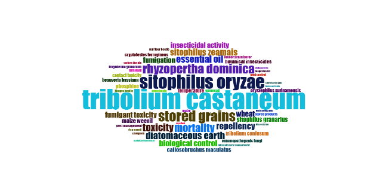

Figure 8. Keyword cloud. Word size reflects the frequency of appearance of each term in the scientific literature.

The thematic trend analysis (Figure 9) shows the temporal distribution of the main keywords in research on postharvest grain conservation. During 2003–2012, terms related to physical and biological control predominated, such as “diatomaceous earth,” *Plodia interpunctella*, and *Beauveria bassiana*, in a context of growing concern over the adverse effects of chemical fumigants. Inert dusts were evaluated for their capacity to desiccate insects without leaving toxic residues in grains [(Mewis & Ulrichs, 2001; Stathers et al., 2002)](https://www.zotero.org/google-docs/?lcqZzW). Entomopathogenic fungi such as *B. bassiana* and *Metarhizium anisopliae* were explored as biological alternatives [(Chatha et al., 2025; Schidt & Wohlgemuth, 1979)](https://www.zotero.org/google-docs/?xphzko). From 2013–2018, the focus shifted toward “botanical insecticides,” “biological control,” and *Anisopteromalus calandrae*. The presence of this parasitoid reflects interest in biological control, and plant-derived insecticides from species such as *Azadirachta indica*, *Moringa oleifera*, and *Ocimum suave* became consolidated as lower-toxicity, more biodegradable alternatives [(Bekele et al., 1996; Kumar & Singh, 2002; Shaizee et al., 2026)](https://www.zotero.org/google-docs/?FjCmlt). During 2018–2021, research returned to specific cereal pests and more traditional methods (*Sitophilus oryzae*, *Rhyzopertha dominica*, “wheat,” and “fumigation”), with an emphasis on the practical application of integrated strategies combining physical methods — such as refrigeration and controlled atmospheres — with chemical and biological treatments depending on the agroecological context [(Armitage et al., 1994; Banks et al., 1980)](https://www.zotero.org/google-docs/?Ta328o). Finally, during 2021–2025, the most current research lines centered on *Tribolium castaneum*, “essential oils,” “insecticidal activity,” and “khapra beetle.” *Trogoderma granarium* gained relevance due to its destructive capacity and resistance to conventional treatments, driving the development of innovative control strategies [(Agrafioti et al., 2025; Gad et al., 2025)](https://www.zotero.org/google-docs/?sjoTUg), while essential oils stood out for their use in nanoencapsulated and synergistic formulations that enhance their efficacy and stability [(Alkan et al., 2026; Kannan & Chandrasekaran, 2026; Santos et al., 2026)](https://www.zotero.org/google-docs/?lc0ykJ). Taken together, this evolution reflects a transition from early physical-biological strategies toward increasingly integrated and nature-based approaches, without implying the abandonment of research on classical stored grain pests.

[figure not shown]

Figure 9. Thematic trend map showing the evolution of research topics between 1944 and mid-2026. Each horizontal line represents the duration of a topic in the literature, and circle size is proportional to its frequency. The most relevant term for each year is highlighted, revealing the emergence, persistence, or decline of research priorities.

The thematic evolution analysis (Figure 10) reveals the dynamics of reorganization and persistence of research concepts over time, demonstrating how initial topics branch and converge in response to scientific advances and applied needs. During 1944–2013, a significant expansion of the thematic system was observed in two main directions. The first was oriented toward the study of specific species, particularly *Sitophilus oryzae* and *Tribolium castaneum*, which emerged as recurrent model organisms due to their cosmopolitan distribution and economic impact. The pioneering works of this period laid the foundations for understanding their biology and ecology, while also developing early detection and control methods [(Loschiavo & Atkinson, 1967, 1973; Waiters & Cox, 1957)](https://www.zotero.org/google-docs/?BiXGrF). The second direction focused on control mechanisms, such as essential oils, entomopathogenic fungi, toxicity, and repellency, which constitute the pillars of what would subsequently consolidate as integrated pest management [(Calderon & Navarro, 1980; Dove & Schroeder, 1955; Rizvi et al., 1980; Storey, 1980)](https://www.zotero.org/google-docs/?PM6Gnl). This line evolved from rudimentary methods, such as the use of metallic mercury [(Dole, 1945; Rahman & Sohi, 1946; Wright, 1944)](https://www.zotero.org/google-docs/?NDA7hF), toward more sophisticated approaches integrating biological agents and botanical compounds. During 2021–2024, a convergence toward more integrative concepts such as “mortality,” “toxicity,” and “biological control” was observed, functioning as common nodes across approaches. This marks a maturation of the field toward unified conceptual frameworks. In this period, the high recurrence of species such as *Callosobruchus chinensis* and *Callosobruchus maculatus* reflects the growing importance of legumes as storage systems and the need for specific strategies for bruchid control [(Mendki et al., 2001; Norton et al., 2025; Patil et al., 2025)](https://www.zotero.org/google-docs/?CgFZ1W). This convergence suggests a transition from reductionist approaches toward systemic perspectives. Finally, during 2025–2026, structural themes such as integrated pest management and grain storage maintained continuity, while connections emerged toward advanced technological approaches such as nanopesticides. This knowledge frontier includes silver, copper, and silica nanoparticles, as well as nanoemulsion formulations, with demonstrated potential for the control of *S. oryzae*, *T. castaneum*, and *Trogoderma granarium*, achieving mortality rates of up to 100% at reduced concentrations [(Chandana et al., 2026; Desai et al., 2026; Hamed et al., 2026; Kadir et al., 2025)](https://www.zotero.org/google-docs/?JEl0ns). *T. castaneum* serves as an element of continuity throughout the entire period, confirming its status as a model organism and its utility as an indicator of the efficacy of new control strategies [(Alfaro-Corres et al., 2025; Yang et al., 2025)](https://www.zotero.org/google-docs/?ZCvAes).

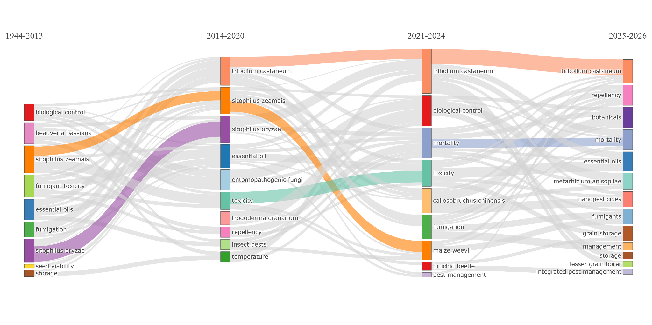

Figure 10. Sankey diagram illustrating thematic evolution divided into four periods (1944–2013, 2014–2020, 2021–2024, and 2025–mid-2026). Each rectangle represents a research topic, whose size indicates its relative importance, and the connecting lines show the continuity or transformation of topics over time.

The thematic map (Figure 11) enabled the classification of research concepts according to their centrality (degree of connection with other topics) and density (degree of internal development), providing a structural overview of the knowledge field. The clusters associated with “mortality,” *Trogoderma granarium* (khapra beetle), and “pest control” occupy the motor themes quadrant, characterized by high centrality and density. The emphasis on *T. granarium* is particularly noteworthy, as this quarantine species has emerged as a critical challenge for food security, driving the integration of modified atmospheres, inert dusts, botanical extracts, and microbial agents [(Al Hamadani et al., 2024; Gad et al., 2025; Kadir et al., 2025)](https://www.zotero.org/google-docs/?ALypON). Its position as a motor theme suggests that research on this pest is driving methodological and theoretical innovations with repercussions across the entire field.

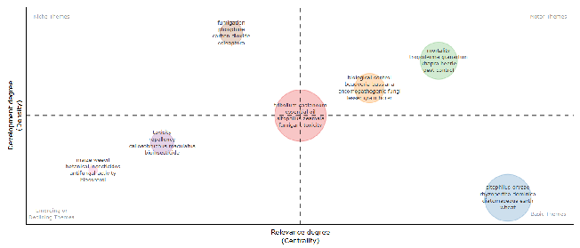

Figure 11. Thematic map classifying keyword clusters according to their centrality (relevance to the field) and density (internal development). The four quadrants distinguish motor themes (high centrality, high density), basic themes (high centrality, low density), emerging or declining themes (low centrality, low density), and niche themes (low centrality, high density).

Similarly, “biological control,” *Beauveria bassiana*, “entomopathogenic fungi,” and the “lesser grain borer” (*Rhyzopertha dominica*) form a well-developed cluster closely linked to sustainable pest management strategies. This cluster, also located in the motor themes quadrant, reflects the consolidation of biological approaches as viable alternatives to synthetic insecticides. Recent studies have evaluated parasitoids such as *Theocolax elegans* [(Flinn & Hagstrum, 2001)](https://www.zotero.org/google-docs/?a3KDOA), entomopathogenic fungi such as *Metarhizium anisopliae* [(Chatha et al., 2025)](https://www.zotero.org/google-docs/?SNDWEk), and their compatibility with other management tactics [(Gonçalves et al., 2002)](https://www.zotero.org/google-docs/?XfyEZa), suggesting that biological control has become a fundamental pillar of integrated pest management in stored grains.

Descriptors related to *Sitophilus oryzae*, *Rhyzopertha dominica*, “diatomaceous earth,” and “wheat” are positioned as basic themes, with high centrality but lower density. This highlights their role as foundational axes of research on grain protection and storage, although they require further internal development to reach the level of consolidation of motor themes. *S. oryzae* and *R. dominica*, as primary pests that infest intact grain, are essential study subjects for understanding infestation mechanisms and evaluating control methods [(Abes et al., 2025; Athanassiou et al., 2003; Hou et al., 2004)](https://www.zotero.org/google-docs/?ukYhAB). Diatomaceous earth, in turn, is a widely studied tool for its efficacy and low environmental impact, although its performance depends on dose, grain type, and environmental conditions [(Korunic et al., 1996; Stathers et al., 2002)](https://www.zotero.org/google-docs/?nQJDiv). In an intermediate position, the cluster comprising *Tribolium castaneum*, *Sitophilus zeamais*, “essential oils,” and “fumigant toxicity” acts as a cross-cutting theme bridging pest species and control methods. *T. castaneum* stands out for its versatility as a model organism in studies of toxicology, resistance genetics, chemical ecology, and physical control [(Ban et al., 2026; Sekar et al., 2021; Yang et al., 2025)](https://www.zotero.org/google-docs/?LAgvYT), while essential oils have demonstrated multiple modes of action — contact toxicity, fumigation, repellency, and reproduction inhibition — making them ideal candidates for integrated management programs [(Ali et al., 2026; Alkan et al., 2026; Santos et al., 2026)](https://www.zotero.org/google-docs/?VEtUBO).

Furthermore, terms such as “maize weevil” (*Sitophilus zeamais*), “botanical insecticides,” “antifungal activity,” “biocontrol,” “toxicity,” “repellency,” and *Callosobruchus maculatus* appear in the emerging or declining themes quadrant, suggesting research lines with limited consolidation. The placement of *S. zeamais* in this quadrant is paradoxical, given that it is a pest of major importance in tropical and subtropical regions. Its reduced presence in recent literature may reflect a shift in focus toward pests of greater quarantine concern, such as *T. granarium*. Botanical insecticides and antifungal activity, while promising, exhibit relatively low density, indicating that they have not yet reached the level of development of other strategies [(Arivoli & Tennyson, 2025; Paster et al., 1995; Shaizee et al., 2026)](https://www.zotero.org/google-docs/?MzntJR). Finally, “fumigation,” “phosphine,” “carbon dioxide,” and “beetles” are positioned as niche themes, with high internal development but limited integration within the broader field. Phosphine fumigation, although still widely used, faces challenges related to insect resistance and risks to human health and the environment, which has reduced research interest in favor of more sustainable alternatives [(Hocking & Banks, 1991)](https://www.zotero.org/google-docs/?YKQpFu). Carbon dioxide, as a component of modified atmospheres, has proven effective; however, its practical application requires specific infrastructure and adequate sealing conditions, which limits its widespread adoption [(Banks et al., 1980; Calderon & Navarro, 1980; Corinth & Rau, 1990)](https://www.zotero.org/google-docs/?Md07Xt).

**3.2. Monitoring and protection of grain storage environments**

**3.2.1. Pest detection, trapping, and monitoring**

The earliest efforts to detect pests consisted of placing water buckets in storage facilities, where adult insects would fall and become trapped [(Waiters & Cox, 1957)](https://www.zotero.org/google-docs/?a7rDKJ). Subsequently, specialized traps were developed, including a perforated cylinder that allowed insect entry but prevented grain passage: insects entered through the perforations and fell into a collecting mesh, with a physical barrier preventing escape [(Loschiavo & Atkinson, 1967)](https://www.zotero.org/google-docs/?8Bnmgl). Later improvements incorporated a removable collecting chamber and corrosion-resistant materials [(Loschiavo & Atkinson, 1973)](https://www.zotero.org/google-docs/?U4jX8O). Subsequently, pit-fall probe traps equipped with food baits, glycerol, and pheromones enabled the monitoring of various pest species [(Fargo et al., 1994)](https://www.zotero.org/google-docs/?u8PrLO), although monitoring efficacy was also found to depend on grain type [(Trematerra, 1998)](https://www.zotero.org/google-docs/?RuqWwv).

In recent years, detection has incorporated digital technologies that automate and extend its reach. Acoustic systems identify the feeding sounds and movement of larvae and adults through digital signal processing and machine learning, facilitating the early detection of hidden infestations [(Mankin et al., 2021)](https://www.zotero.org/google-docs/?iZS1y8). Complementarily, Internet of Things (IoT)-based devices monitor variables such as temperature, humidity, and gas concentration in real time, triggering automated alerts or ventilation when critical thresholds are exceeded [(Abiram et al., 2025)](https://www.zotero.org/google-docs/?3QVhmt). Taken together, these advances reflect a transition from mechanical detection methods toward intelligent systems capable of anticipating infestations before they result in significant losses.

**3.2.2. Packaging materials and hermetic technologies**

Research on packaging materials has evolved toward hermetic systems that restrict gas exchange and create adverse conditions for pests. Early studies evaluated hermetic silos, in which adequate sealing enabled the generation of controlled atmospheres [(Chantler, 1984)](https://www.zotero.org/google-docs/?j4tDkS). This approach was extended to sealed underground structures, where heat and mass transfer models combined with remote monitoring maintained grain in a dormant state and controlled insects, mites, and fungi (Dunkel, 1995). Traditional structures were also analyzed, such as granaries with slatted floors that improve air circulation and regulate temperature [(Saá et al., 2011)](https://www.zotero.org/google-docs/?h9Ajxy).

The most significant advance has been the introduction of triple-layer hermetic bags, such as PICS bags, which prevent insect population growth and preserve grain germination [(Martin et al., 2015; Mendesil et al., 2022)](https://www.zotero.org/google-docs/?LVbaId). These bags reduce oxygen levels and increase carbon dioxide concentrations, suppressing pest development [(Mutambuki et al., 2019)](https://www.zotero.org/google-docs/?9Uhqdc). Various brands of hermetic bags have shown comparable efficacy among themselves, outperforming synthetic insecticides [(Ngwenyama et al., 2022)](https://www.zotero.org/google-docs/?7lLg4C), and other technologies, such as SuperGrainBag® bags, have also inhibited pests and diseases [(Diarra & Amoah, 2019)](https://www.zotero.org/google-docs/?NNW1yx). The “dry chain” strategy — initial drying followed by hermetic storage — has reduced pest infestations [(Bakhtavar et al., 2019)](https://www.zotero.org/google-docs/?0c2flb), and recent studies confirm that hermetic bags maintain stable moisture levels and prevent pest damage without affecting germination, unlike polypropylene bags [(Odjo et al., 2022; Rizwan et al., 2022)](https://www.zotero.org/google-docs/?fvruHb). Polypropylene-reinforced jute sacks have further improved mechanical resistance and reduced permeability, significantly decreasing pest-related losses compared to conventional sacks [(Dubey et al., 2026)](https://www.zotero.org/google-docs/?VD7BKf). A more recent development is biopesticide bags incorporating essential oils into the inner layer, which release the active compound gradually and have achieved complete pest elimination in controlled trials [(Herrera et al., 2021)](https://www.zotero.org/google-docs/?EmPrTk).

**3.2.3. Protection of grain storage environments**

The protection of grain storage environments has addressed infrastructure design, physical barriers, and fumigation systems. Studies on traditional granaries demonstrated that internal ventilation regulates temperature and promotes grain conservation [(Saá et al., 2011)](https://www.zotero.org/google-docs/?MpGcyn). Research on the waterproofing of underground granaries has led to the development of reinforced plastic concrete systems [(Zhang et al., 2022)](https://www.zotero.org/google-docs/?HpX7ff), while metal silos have been shown to maintain grain quality and moisture under arid conditions [(Shimbwadala et al., 2025)](https://www.zotero.org/google-docs/?7MiyPg). Physical barriers have gained relevance as complementary strategies. Permethrin-treated mosquito nets have controlled pests by wrapping storage containers [(Anaclerio et al., 2015)](https://www.zotero.org/google-docs/?RYWd24), long-lasting insecticide-impregnated nets have reduced insect dispersal and grain damage [(Ranabhat et al., 2025)](https://www.zotero.org/google-docs/?zF9ZYA), and polypropylene bags incorporating deltamethrin have limited beetle survival and grain access [(Kavallieratos et al., 2017)](https://www.zotero.org/google-docs/?1h6Vgf).

Phosphine fumigation remains central to storage environment protection. Its application has been optimized through thermosiphon systems that enable more uniform and safer distribution [(Doran, 2024)](https://www.zotero.org/google-docs/?jPdNLM), achieving near-complete pest control at adequate concentrations [(Arora et al., 2025)](https://www.zotero.org/google-docs/?Ii4G6M), particularly in hermetic concrete silos [(Kljajić et al., 2026)](https://www.zotero.org/google-docs/?LXUhrf). As an alternative, cold smoke generators using low-temperature aerosols have achieved effective and rapid pest control [(Guo et al., 2026)](https://www.zotero.org/google-docs/?xhE5zk). The integration of these strategies has begun to converge toward automated management systems: granaries that combine data analytics, oxygen regulation, insecticide dosing, and thermal control to optimize conservation conditions without constant manual intervention [(Shen, 2022)](https://www.zotero.org/google-docs/?rRXsE5).

**3.2.4. Technological adoption, research gaps, and future perspectives**

Despite the demonstrated efficacy of hermetic technologies, their adoption faces significant barriers in smallholder farming systems. Studies have identified that, although the majority of farmers are aware of hermetic bags, only a minority use them regularly, owing to high costs, limited local availability, and insufficient knowledge of their correct use. Adoption is further influenced by factors such as the age of the household head, family size, and participation in agricultural projects, suggesting that sustainable implementation requires improving accessibility, reducing costs, and strengthening training [(Nakoma Ngoma et al., 2025)](https://www.zotero.org/google-docs/?s3A43x).

This adoption gap is linked to broader research gaps. A considerable distance persists between studies conducted under laboratory conditions and their application in real storage scenarios, where factors such as environmental fluctuations, available infrastructure, and mixed pest populations may alter treatment efficacy. Likewise, although nanopesticides and nanoformulations have shown promising results, further investigation into their mechanisms of action and long-term effects on grain quality and food safety remains necessary. Insecticide resistance continues to be a relevant challenge, particularly in species such as *Tribolium castaneum*, which demands management strategies integrating multiple control methods. Finally, studies directly addressing the socioeconomic and cultural barriers that limit the adoption of sustainable technologies are needed — a key aspect for achieving an effective transfer of scientific knowledge into agricultural practice.

Looking ahead, research should focus on validating these emerging technologies — including nanopesticides, nanoencapsulated formulations, and intelligent monitoring systems — under real storage conditions, moving beyond the purely experimental scope that has predominated to date. It is equally necessary to consolidate integrated strategies that combine biological, physical, and digital approaches to counteract pest resistance and progressively reduce dependence on synthetic insecticides. In parallel, research aimed at facilitating access, adoption, and scalability of these solutions in smallholder farming systems is of particular importance, so that the knowledge generated may be translated into concrete actions to reduce postharvest losses and strengthen food security at a global scale.

**3.3. Study limitations**

The study presents relevant findings, albeit with limitations. The use of a single database may have restricted the retrieval of relevant publications; future studies should therefore integrate multiple sources to broaden coverage. Likewise, the search query — centered on the terms “postharvest grain storage,” “stored grain,” and “grain preservation” — although effective in delimiting the corpus with specificity, may have excluded relevant studies that did not include these exact terms in the title, abstract, or keywords, particularly those focused on specific pest species or control strategies without direct reference to postharvest storage. Future reviews could expand the search query or validate it against a reference set of well-established studies in the field to assess its sensitivity. Regarding the analytical tools, VOSviewer and Bibliometrix facilitated the analysis but require technical expertise and careful data preprocessing, as the accuracy of the results depends on the appropriate configuration of parameters.

**3.4. Conclusions**

With respect to monitoring and protection strategies, an evolution was observed toward integrated systems combining physical, hermetic, and digital technologies — ranging from specialized traps and acoustic sensors to triple-layer hermetic bags and real-time IoT monitoring devices. However, their adoption remains constrained by economic, availability, and technical training factors, confirming that the effective transfer of these innovations to end users continues to be one of the primary challenges in achieving safer, more efficient, and more sustainable grain storage systems.

## 1.1 **CRediT author contribution statement**

**Wagner Meza-Maicelo:** Writing – review and editing, Writing – original draft, Visualization, Resources, Methodology, Formal analysis, Data curation. **Victor-Hugo Baldera-Chapoñan:** Writing – review and editing, Visualization, Methodology, Formal analysis. **Damaris Leiva-Tafur**: Formal analysis, Data curation. **Manuel Oliva-Cruz:** Writing – review and editing, Resources. **Flavio Lozano-Isla:** Writing – review and editing, Resources, Project administration.

**Funding**

This research and the Article Processing Charge (APC) were funded by the Vice-Rectorate for Research of the *Universidad Nacional Toribio Rodríguez de Mendoza de Amazonas* (UNTRM). The authors gratefully acknowledge the technical and financial support provided by the CUI Project No. 2590588, *“Improvement of the Science, Technology, and Innovation Promotion Service for the Research Center in Grains and Seeds (CEIGRAS)”* at UNTRM.

**Declaration of competing interests**

The authors declare that there are no financial interests or personal relationships that have influenced, or could have influenced, the conduct or outcomes of the present study.

**Acknowledgements**

The authors express their sincere gratitude to the *Instituto de Investigación para el* *Desarrollo Sustentable de Ceja de Selva (INDES-CES)*.

**Data availability**

All datasets, R scripts, and reproducible analytical workflows are provided in the Supplementary Material. The complete dataset and analysis code are also available in the public GitHub repository:

https://github.com/WAHGNERM2002/GrainStorage

# 2 **References**

[Abes, I. F. Z., Soltani, M., Ayad, A. S., Tine, S., Tine-Djebbar, F., & Soltani, N. (2025). Fumigant toxicity of Eucalyptus globulus essential oil and its constituents against Rhyzopertha dominica (Coleoptera: Bostrichidae) and their repellent and acetylcholinesterase inhibitory activity. *Journal of Stored Products Research*, *114*, 102789. https://doi.org/10.1016/j.jspr.2025.102789](https://www.zotero.org/google-docs/?SiK2P4)

[Abiram, A., Dharun, K., & Srinivasan, S. (2025). Iot-Based Real-Time Rice Storage and Preservation System. *2025 10th International Conference on Communication and Electronics Systems (ICCES)*, 1188-1192. https://doi.org/10.1109/ICCES67310.2025.11337135](https://www.zotero.org/google-docs/?SiK2P4)

[Afful, E., Cato, A., Nayak, M. K., & Phillips, T. W. (2021). A rapid assay for the detection of resistance to phosphine in the lesser grain borer, *Rhyzopertha dominica* (F.) (Coleoptera: Bostrichidae). *Journal of Stored Products Research*, *91*, 101776. https://doi.org/10.1016/j.jspr.2021.101776](https://www.zotero.org/google-docs/?SiK2P4)

[Agrafioti, P., Lampiri, E., Kaloudis, E., Gourgouta, M., Vassilakos, T. N., Ioannidis, P. M., & Athanassiou, C. G. (2024). Spatio-Temporal Distribution of Stored Product Insects in a Feed Mill in Greece. *Agronomy*, *14*(12), 2812. https://doi.org/10.3390/agronomy14122812](https://www.zotero.org/google-docs/?SiK2P4)

[Agrafioti, P., Morrison, W. R., Domingue, M., Lampiri, E., Myers, S. W., & Athanassiou, C. G. (2025). Estimating the efficacy and plume reach of semiochemical‐baited traps on the capture of *Trogoderma granarium* everts. *Pest Management Science*, *81*(8), 4471-4480. https://doi.org/10.1002/ps.8805](https://www.zotero.org/google-docs/?SiK2P4)

[Al Hamadani, A. H. A., Al-fatlawi, M. K. M., & Hadi, M. H. (2024). Efficacy of Some Aquatic Plant Extracts on the Khapra Beetle *Trogoderma Granarium* Everts. *Indian Journal of Entomology*, 1-4. https://doi.org/10.55446/IJE.2024.1938](https://www.zotero.org/google-docs/?SiK2P4)

[Alfaro-Corres, A., González Mendoza, D., Ruiz-Sánchez, E., Valdez-Salas, B., Mendez-Trujillo, V., & Beltran-Partida, E. (2025). FITO-NANOPARTÍCULAS METÁLICAS Y SU ACTIVIDAD INSECTICIDA CONTRA EL GORGOJO ROJO (Tribolium castaneum) Y EL PIOJO HARINOSO (Phenanoccus solenopsis). *Chilean journal of agricultural & animal sciences*, *41*(3), 397-407. https://doi.org/10.29393/CHJAAS41-35FNAB60035](https://www.zotero.org/google-docs/?SiK2P4)

[Ali, F., Qureshi, M., Mumtaz, M., Abbasi, K., Binyameen, M., El-Seedi, H. R., Borg-Karlson, A. K., Mozūratis, R., & Azeem, M. (2026). Chemical composition of essential oils and solvent extracts of Artemisia scoparia, Seriphidium brevifolium, and Salvia yangii and their comparative fumigant toxicity against stored-grain pests Tribolium castaneum and Sitophilus oryzae. *Discover Food*, *6*(1), 50. https://doi.org/10.1007/s44187-026-00818-y](https://www.zotero.org/google-docs/?SiK2P4)

[Alkan, M., Evli̇ce, E., Ertürk, S., Karakoç, Ö. C., Yücel, Y. Y., Bağdat, R. B., Tüfekçi̇, A. R., & Yırtıcı, Ü. (2026). Biological activities of Tanacetum sp. essential oils on Tribolium castaneum (Herbst, 1797) (Coleoptera: Tenebrionidae) and Sitophilus granarius (Linnaeus, 1758) (Coleoptera: Curculionidae). *Journal of Stored Products Research*, *117*, 103001. https://doi.org/10.1016/j.jspr.2026.103001](https://www.zotero.org/google-docs/?SiK2P4)

[Alwaneen, W. S., Tahir, M., Avery, P. B., Wakil, W., Kavallieratos, N. G., Eleftheriadou, N., Boukouvala, M. C., Rasool, K. G., Husain, M., & Aldawood, A. S. (2024). Initial Evaluation of the Entomopathogenic Fungi Beauveria bassiana and Metarhizium robertsii, and the Entomopathogenic Nematode Heterorhabditis bacteriophora, Individually and in Combination against the Noxious Helicoverpa armigera (Lepidoptera: Noctuidae). *Agronomy*, *14*(7), 1395. https://doi.org/10.3390/agronomy14071395](https://www.zotero.org/google-docs/?SiK2P4)

[Anaclerio, M., Pellizzoni, M., Todeschini, V., Trevisan, M., & Bertoni, G. (2015). Use of permethrin coated nets to protect stored grain from pests infestations. *Envisioning a Future without Food Waste and Food Poverty*, 119-124. https://doi.org/10.3920/978-90-8686-820-9_13](https://www.zotero.org/google-docs/?SiK2P4)

[Aria, M., & Cuccurullo, C. (2016). *bibliometrix: Comprehensive Science Mapping Analysis* (p. 5.4.1) [Dataset]. https://doi.org/10.32614/CRAN.package.bibliometrix](https://www.zotero.org/google-docs/?SiK2P4)

[Arivoli, S., & Tennyson, S. (2025). Assessment of insecticidal efficacy of aromatic plant leaf oil extracts on the adults of Sitophilus oryzae Linnaeus 1763 (Coleoptera: Curculionidae) and Tribolium castaneum Herbst 1797 (Coleoptera: Tenebrionidae). *Journal of Natural Pesticide Research*, *14*, 100171. https://doi.org/10.1016/j.napere.2025.100171](https://www.zotero.org/google-docs/?SiK2P4)

[Armitage, D. M., Cogan, P. M., & Wilkin, D. R. (1994). Integrated pest management in stored grain: Combining surface insecticide treatments with aeration. *Journal of Stored Products Research*, *30*(4), 303-319. https://doi.org/10.1016/S0022-474X(94)90322-0](https://www.zotero.org/google-docs/?SiK2P4)

[Arora, S., Patil, N., Adak, T., Jena, M., & Srivastava, C. (2025). Optimizing phosphine applications for insect control in Bagged rice stored in Indian warehouses. *Journal of Stored Products Research*, *111*, 102584. https://doi.org/10.1016/j.jspr.2025.102584](https://www.zotero.org/google-docs/?SiK2P4)

[Athanassiou, C. G., Kavallieratos, N. G., Tsaganou, F. C., Vayias, B. J., Dimizas, C. B., & Buchelos, C. T. (2003). Effect of grain type on the insecticidal efficacy of SilicoSec against Sitophilus oryzae (L.) (Coleoptera: Curculionidae). *Crop Protection*, *22*(10), 1141-1147. https://doi.org/10.1016/S0261-2194(03)00155-8](https://www.zotero.org/google-docs/?SiK2P4)

[Bakhtavar, M. A., Afzal, I., Basra, S. M. A., & Wahid, A. (2019). Implementing the ‘dry chain’ during storage reduces losses and maintains quality of maize grain. *Food Security*, *11*(2), 345-357. https://doi.org/10.1007/s12571-019-00905-2](https://www.zotero.org/google-docs/?SiK2P4)

[Ban, J.-H., Yoo, J.-S., Choi, J.-E., Kim, J.-R., & Kim, B.-S. (2026). Synergistic toxicity assessment of ethyl formate combined with low-oxygen and cold treatments against the red flour beetle, Tribolium castaneum Herbst. *Journal of Stored Products Research*, *115*, 102802. https://doi.org/10.1016/j.jspr.2025.102802](https://www.zotero.org/google-docs/?SiK2P4)

[Banks, H. J., Annis, P. C., Henning, R. C., & Wilson, A. D. (1980). Experimental and Commercial Modified Atmosphere Treatments of Stored Grain in Australia. En J. Shejbal (Ed.), *Controlled Atmosphere Storage of Grains* (Vol. 1, pp. 207-224). Elsevier. https://doi.org/10.1016/B978-0-444-41939-2.50025-5](https://www.zotero.org/google-docs/?SiK2P4)

[Bekele, A. J., Obeng‐ofori, D., & Hassanali, A. (1996). Evaluation of Ocimum suave (Willd) as a source of repellents, toxicants and protectants in storage against three stored product insect pests. *International Journal of Pest Management*, *42*(2), 139-142. https://doi.org/10.1080/09670879609371983](https://www.zotero.org/google-docs/?SiK2P4)

[Bohinc, T., Agrafioti, P., Vasilopoulos, S., Lampiri, E., Boukouvala, M. C., Skourti, A., Gidari, D. L. S., Kavallieratos, N. G., Pons, X., Levi-Mourao, A., Domínguez Solera, E., Benavent Fernandez, E., Roig Pinãs, A., Athanassiou, C. G., & Trdan, S. (2025). Suitability of Three Trunk Traps for Capturing Larvae of Lymantria dispar (L.) (Lepidoptera, Erebidae). *Insects*, *16*(5), 522. https://doi.org/10.3390/insects16050522](https://www.zotero.org/google-docs/?SiK2P4)

[Boukaew, S., Petlamul, W., Yossan, S., Srinuanpan, S., Nooprom, K., & Zhang, Z. (2024). Biofumigant potential and inhibition mechanism of Trichoderma asperelloides SKRU-01 volatile organic compounds for controlling aflatoxigenic Aspergillus parasiticus and Aspergillus flavus in stored peanuts. *Food Control*, *157*, 110194. https://doi.org/10.1016/j.foodcont.2023.110194](https://www.zotero.org/google-docs/?SiK2P4)

[Calderon, M., & Navarro, S. (1980). Efecto sinérgico de mezclas de CO₂ y O₂ sobre dos plagas de insectos en granos almacenados *. En J. Shejbal (Ed.), *Controlled Atmosphere Storage of Grains* (Vol. 1, pp. 79-84). Elsevier. https://doi.org/10.1016/B978-0-444-41939-2.50013-9](https://www.zotero.org/google-docs/?SiK2P4)

[Callon, M., Courtial, J. P., & Laville, F. (1991). Co-word analysis as a tool for describing the network of interactions between basic and technological research: The case of polymer chemsitry. *Scientometrics*, *22*(1), 155-205. https://doi.org/10.1007/BF02019280](https://www.zotero.org/google-docs/?SiK2P4)

[Cato, A., Afful, E., Nayak, M. K., & Phillips, T. W. (2019). Evaluation of Knockdown Bioassay Methods to Assess Phosphine Resistance in the Red Flour Beetle, Tribolium castaneum (Herbst) (Coleoptera: Tenebrionidae). *Insects*, *10*(5), 140. https://doi.org/10.3390/insects10050140](https://www.zotero.org/google-docs/?SiK2P4)

[Chandana, C. R., Kalita, S., V., R., & Kaman, P. K. (2026). Biogenic silver nanoparticles as seed protectant for stored paddy seeds against Sitophilus oryzae (L.) (Coleoptera: Curculionidae). *International Journal of Tropical Insect Science*. https://doi.org/10.1007/s42690-026-01754-1](https://www.zotero.org/google-docs/?SiK2P4)

[Chantler, D. (1984). The Adoption of Silo Sealing by Western Australian Farmers. En B. E. Ripp (Ed.), *Controlled Atmosphere and Fumigation in Grain Storages* (Vol. 5, pp. 683-705). Elsevier. https://doi.org/10.1016/B978-0-444-42417-4.50069-4](https://www.zotero.org/google-docs/?SiK2P4)

[Chatha, A. A., Asrar, M., Zia, K., Saleem, U., Malik, S., Javed, Z., Usman, H., & Saleem, M. (2025). Pathogenicity of Metarhizium anisopliae (Pacer) against two stored-grain insect pests under abiotic stress factors. *Plant Protection*, *9*(3), 735-743. https://doi.org/10.33804/pp.009.03.5574](https://www.zotero.org/google-docs/?SiK2P4)

[Corinth, H. G., & Rau, G. (1990). Vorratsschutz mit Kohlendioxid. *Anzeiger für Schädlingskunde, Pflanzenschutz, Umweltschutz*, *63*(7), 121-123. https://doi.org/10.1007/BF02033945](https://www.zotero.org/google-docs/?SiK2P4)

[Daglish, G. J., Nayak, M. K., Arthur, F. H., & Athanassiou, C. G. (2018). Insect Pest Management in Stored Grain. En C. G. Athanassiou & F. H. Arthur (Eds.), *Recent Advances in Stored Product Protection* (pp. 45-63). Springer Berlin Heidelberg. https://doi.org/10.1007/978-3-662-56125-6_3](https://www.zotero.org/google-docs/?SiK2P4)

[del Arco, L., Riudavets, J., Miguel Campos-Rivela, J., Teresa Martínez-Ferrer, M., Agustí, N., & Castañé, C. (2023). Eficacia del parasitoide *Anisopteromalus calandrae* (Hymenoptera: Pteromalidae) en el control de *Sitophilus zeamais* y *Rhyzopertha dominica* en arrozales. *Biological Control*, *181*, 105216. https://doi.org/10.1016/j.biocontrol.2023.105216](https://www.zotero.org/google-docs/?SiK2P4)

[Desai, K. C., Kambrekar, D. N., Naveen, V., Krishnaraj, P. U., Biradar, S., Sugandi, R., Chandrashekhar, S. S., T, S. K., & Jepi, V. D. (2026). Investigations on sweet flag (Acorus calamus L.) based silver and zinc nanoparticles against Sitophilus oryzae L. in wheat. *Journal of Stored Products Research*, *116*, 102945. https://doi.org/10.1016/j.jspr.2025.102945](https://www.zotero.org/google-docs/?SiK2P4)

[Diarra, M., & Amoah, R. S. (2019). Physical factors in the hermetic SuperGrainBag® and effect on the larger grain borer [Prostephanus truncatus (Horn) (Coleoptera: Bostrichidae)] and aflatoxin production by Aspergillus flavus during the storage of ‘Obatanpa’ maize (Zea mays L.) variety. *Journal of Stored Products Research*, *83*, 84-91. https://doi.org/10.1016/j.jspr.2019.05.016](https://www.zotero.org/google-docs/?SiK2P4)

[Dole, K. K. (1945). Physico-chemical aspects of the application of mercury towards preservation of stored food grains. *Proceedings / Indian Academy of Sciences*, *22*(3), 133-143. https://doi.org/10.1007/BF03048772](https://www.zotero.org/google-docs/?SiK2P4)

[Donthu, N., Kumar, S., Mukherjee, D., Pandey, N., & Lim, W. M. (2021). How to conduct a bibliometric analysis: An overview and guidelines. *Journal of Business Research*, *133*, 285-296. https://doi.org/10.1016/j.jbusres.2021.04.070](https://www.zotero.org/google-docs/?SiK2P4)

[Doran, G. S. (2024). The effectiveness of phosphine fumigation of wheat in a farm-scale thermosyphon silo. *Journal of Stored Products Research*, *109*, 102414. https://doi.org/10.1016/j.jspr.2024.102414](https://www.zotero.org/google-docs/?SiK2P4)

[Dove, W. E., & Schroeder, H. O. (1955). Granary Insecticides, Protection of Stored Grain with Sprays of Pyrethrins-Piperonyl Butoxide Emulsion. *Journal of Agricultural and Food Chemistry*, *3*(11), 932-936. https://doi.org/10.1021/jf60057a002](https://www.zotero.org/google-docs/?SiK2P4)

[Dubey, A., Mani, I., Chandni, Parray, R. A., Nebapure, S. M., & Rudra, S. G. (2026). Comparison of jute gunny bags with and without polypropylene for gram storage. *Journal of Stored Products Research*, *115*, 102881. https://doi.org/10.1016/j.jspr.2025.102881](https://www.zotero.org/google-docs/?SiK2P4)

[Edwards, J. P., Short, J. E., & Abraham, L. (1991). Large-scale evaluation of the insect juvenile hormone analogue fenoxycarb as a long-term protectant of stored wheat. *Journal of Stored Products Research*, *27*(1), 31-39. https://doi.org/10.1016/0022-474X(91)90030-G](https://www.zotero.org/google-docs/?SiK2P4)

[Erenstein, O., Jaleta, M., Sonder, K., Mottaleb, K., & Prasanna, B. M. (2022). Global maize production, consumption and trade: Trends and R&D implications. *Food Security*, *14*(5), 1295-1319. https://doi.org/10.1007/s12571-022-01288-7](https://www.zotero.org/google-docs/?SiK2P4)

[Fargo, W. S., Cuperus, G. W., Bonjour, E. L., Burkholder, W. E., Clary, B. L., & Payton, M. E. (1994). Influence of probe trap type and attractants on the capture of four stored-grain Coleoptera. *Journal of Stored Products Research*, *30*(3), 237-241. https://doi.org/10.1016/0022-474X(94)90051-I](https://www.zotero.org/google-docs/?SiK2P4)

[Feeding the Future Global Population. (2024). *Alimentar a la futura población mundial | Nature Communications*. *15*(222). https://doi.org/10.1038/s41467-023-44588-y](https://www.zotero.org/google-docs/?SiK2P4)

[Fleurat-Lessard, F. (2017). Integrated management of the risks of stored grain spoilage by seedborne fungi and contamination by storage mould mycotoxins – An update. *Journal of Stored Products Research*, *71*, 22-40. https://doi.org/10.1016/j.jspr.2016.10.002](https://www.zotero.org/google-docs/?SiK2P4)

[Flinn, P. W., & Hagstrum, D. W. (2001). Augmentative releases of parasitoid wasps in stored wheat reduces insect fragments in flour. *Journal of Stored Products Research*, *37*(2), 179-186. https://doi.org/10.1016/S0022-474X(00)00018-7](https://www.zotero.org/google-docs/?SiK2P4)

[Forbanka, D. N. (2021). Post-Harvest Storage Practices and Insect Pests of Maize and Beans in the North West Region of Cameroon. *African Entomology*, *29*(1). https://doi.org/10.4001/003.029.0133](https://www.zotero.org/google-docs/?SiK2P4)

[Fukagawa, N. K., & Ziska, L. H. (2019). Rice: Importance for Global Nutrition. *Journal of Nutritional Science and Vitaminology*, *65*(Supplement), S2-S3. https://doi.org/10.3177/jnsv.65.S2](https://www.zotero.org/google-docs/?SiK2P4)

[Gad, H. A., El-Deeb, S. E., Atta, A. A. M., Al-Anany, F. S., & Abdelgaleil, S. A. M. (2025). Integrating inert dusts with carbon dioxide as an ecofriendly approach for the control of Trogoderma granarium everts. *Journal of Plant Diseases and Protection*, *132*(5), 144. https://doi.org/10.1007/s41348-025-01140-y](https://www.zotero.org/google-docs/?SiK2P4)

[Gazni, A., Sugimoto, C. R., & Didegah, F. (2012). Mapping world scientific collaboration: Authors, institutions, and countries. *Journal of the American Society for Information Science and Technology*, *63*(2), 323-335. https://doi.org/10.1002/asi.21688](https://www.zotero.org/google-docs/?SiK2P4)

[Gonçalves, J. R., Faroni, L. R. D., & Guedes, R. N. C. (2002). Pyrethroid-Acarophenax lacunatus interaction in suppressing the beetle Rhyzopertha dominica on stored wheat. *Experimental & Applied Acarology*, *26*(3-4), 231-242. https://doi.org/10.1023/A:1021196601287](https://www.zotero.org/google-docs/?SiK2P4)

[Guo, L., An, X., Cao, L., Liu, S., Wang, A., Yang, S., Huang, N., Wang, F., Ren, L., & Cao, A. (2026). Cold smoke generator a novel supplement to aluminum phosphide as a delivery platform in stored-grain pest management. *Journal of Stored Products Research*, *117*, 103034. https://doi.org/10.1016/j.jspr.2026.103034](https://www.zotero.org/google-docs/?SiK2P4)

[Hamed, S., Sayed, R. M., Mo’men, S. A. A., Sayed, A., & Barakat, E. M. S. (2026). From wheat to wheat: Synergistic effect of silica nanoparticles synthesized from wheat straw assisted by gamma irradiation against khapra beetle, Trogoderma granarium everts on wheat grain. *Beni-Suef University Journal of Basic and Applied Sciences*, *15*(1), 34. https://doi.org/10.1186/s43088-026-00751-0](https://www.zotero.org/google-docs/?SiK2P4)

[Hashem, A. S., Awadalla, S. S., Zayed, G. M., Maggi, F., & Benelli, G. (2018). Pimpinella anisum essential oil nanoemulsions against Tribolium castaneum—Insecticidal activity and mode of action. *Environmental Science and Pollution Research*, *25*(19), 18802-18812. https://doi.org/10.1007/s11356-018-2068-1](https://www.zotero.org/google-docs/?SiK2P4)

[Herrera, J. M., Zygadlo, J. A., Strumia, M. C., & Peralta, E. (2021). Biopesticidal silo bag prepared by co-extrusion process. *Food Packaging and Shelf Life*, *28*, 100645. https://doi.org/10.1016/j.fpsl.2021.100645](https://www.zotero.org/google-docs/?SiK2P4)

[Hocking, A. D., & Banks, H. J. (1991). Effects of phosphine fumigation on survival and growth of storage fungi in wheat. *Journal of Stored Products Research*, *27*(2), 115-120. https://doi.org/10.1016/0022-474X(91)90021-4](https://www.zotero.org/google-docs/?SiK2P4)

[Hou, X., Fields, P., Flinn, P., Perez-Mendoza, J., & Baker, J. (2004). Control of Stored-Product Beetles with Combinations of Protein-Rich Pea Flour and Parasitoids. *Environmental Entomology*, *33*(3), 671-680. https://doi.org/10.1603/0046-225X-33.3.671](https://www.zotero.org/google-docs/?SiK2P4)

[Jian, F. (2025). Management strategy evaluation of stored grain using global sensitivity analysis: Part I – Allowable maximum variations of temperatures and moisture contents of canola. *Journal of Stored Products Research*, *112*, 102649. https://doi.org/10.1016/j.jspr.2025.102649](https://www.zotero.org/google-docs/?SiK2P4)

[Kadir, M. L., Dageri, A., & Aslan, T. N. (2025). Insecticidal efficacy of green-synthesized copper nanoparticles and their impact on detoxification genes in the khapra beetle. *Journal of Environmental Science and Health, Part B*, *60*(6), 253-265. https://doi.org/10.1080/03601234.2025.2501355](https://www.zotero.org/google-docs/?SiK2P4)

[Kannan, N., & Chandrasekaran, N. (2026). Targeting Tribolium castaneum with nanoemulsified essential oils: A green approach to pest control. *Journal of Stored Products Research*, *115*, 102829. https://doi.org/10.1016/j.jspr.2025.102829](https://www.zotero.org/google-docs/?SiK2P4)

[Katranas, G. C., Vassilakos, T. N., Rumbos, C. I., & Athanassiou, C. G. (2024). Effect of Trap Type and Height on the Captures of the Pink Bollworm, Pectinophora gossypiella (Saunders) (Lepidoptera: Gelechiidae), in Pheromone-Baited Traps in Cotton. *Agronomy*, *14*(4), 656. https://doi.org/10.3390/agronomy14040656](https://www.zotero.org/google-docs/?SiK2P4)

[Kavallieratos, N. G., Athanassiou, C. G., & Arthur, F. H. (2017). Effectiveness of insecticide-incorporated bags to control stored-product beetles. *Journal of Stored Products Research*, *70*, 18-24. https://doi.org/10.1016/j.jspr.2016.11.001](https://www.zotero.org/google-docs/?SiK2P4)

[Keszthelyi, S., Lukács, H., & Pál-Fám, F. (2021). Effects of Different Infra-Red Irradiations on the Survival of Granary Weevil Sitophilus granarius: Bioefficacy and Sustainability. *Insects*, *12*(2), 102. https://doi.org/10.3390/insects12020102](https://www.zotero.org/google-docs/?SiK2P4)

[Kljajić, P., Andrić, G., & Pražić Golić, M. (2026). Impact of commercial phosphine fumigation of stored-grains in concrete silos on survival and progeny of natural free-living insect pests. *Journal of Stored Products Research*, *116*, 102895. https://doi.org/10.1016/j.jspr.2025.102895](https://www.zotero.org/google-docs/?SiK2P4)

[Korunic, Z., Fields, P. G., Kovacs, M. I. P., Noll, J. S., Lukow, O. M., Demianyk, C. J., & Shibley, K. J. (1996). The effect of diatomaceous earth on grain quality. *Postharvest Biology and Technology*, *9*(3), 373-387. https://doi.org/10.1016/S0925-5214(96)00038-5](https://www.zotero.org/google-docs/?SiK2P4)

[Kumar, M., & Singh, R. (2002). Potential of *Pongamia glabra* Vent as an Insecticide of Plant Origin. *Biological Agriculture & Horticulture*, *20*(1), 29-50. https://doi.org/10.1080/01448765.2002.9754947](https://www.zotero.org/google-docs/?SiK2P4)

[Lampiri, E., Agrafioti, P., Kaloudis, E., Kateris, D., & Athanassiou, C. G. (2025). Diversity and Seasonal Dynamics of Stored-Product Insects in a Feed Manufacturing Facility in Greece. *Insects*, *16*(12), 1209. https://doi.org/10.3390/insects16121209](https://www.zotero.org/google-docs/?SiK2P4)

[Lee, B.-H., Annis, P. C., Tumaalii, F., & Choi, W.-S. (2004). Fumigant toxicity of essential oils from the Myrtaceae family and 1,8-cineole against 3 major stored-grain insects. *Journal of Stored Products Research*, *40*(5), 553-564. https://doi.org/10.1016/j.jspr.2003.09.001](https://www.zotero.org/google-docs/?SiK2P4)

[Lee, B.-H., Choi, W.-S., Lee, S.-E., & Park, B.-S. (2001). Fumigant toxicity of essential oils and their constituent compounds towards the rice weevil, *Sitophilus oryzae* (L.). *Crop Protection*, *20*(4), 317-320. https://doi.org/10.1016/S0261-2194(00)00158-7](https://www.zotero.org/google-docs/?SiK2P4)

[Long, J. C., Cunningham, F. C., & Braithwaite, J. (2013). Bridges, brokers and boundary spanners in collaborative networks: A systematic review. *BMC Health Services Research*, *13*(1), 158. https://doi.org/10.1186/1472-6963-13-158](https://www.zotero.org/google-docs/?SiK2P4)

[Longstaff, B. C. (1988). Manipulación de la temperatura y manejo de la resistencia a los insecticidas en plagas de granos almacenados: Un estudio de simulación para el gorgojo del arroz, *Sitophilus oryzae. Ecological Modelling*, *43*(3), 303-313. https://doi.org/10.1016/0304-3800(88)90010-5](https://www.zotero.org/google-docs/?SiK2P4)

[Loschiavo, S. R., & Atkinson, J. M. (1967). UNA TRAMPA PARA LA DETECCIÓN Y RECUPERACIÓN DE INSECTOS EN GRANOS ALMACENADOS. *The Canadian Entomologist*, *99*(11), 1160-1163. https://doi.org/10.4039/Ent991160-11](https://www.zotero.org/google-docs/?SiK2P4)

[Loschiavo, S. R., & Atkinson, J. M. (1973). UNA TRAMPA MEJORADA PARA DETECTAR ESCARABAJOS (COLEOPTERA) EN GRANOS ALMACENADOS. *The Canadian Entomologist*, *105*(3), 437-440. https://doi.org/10.4039/Ent105437-3](https://www.zotero.org/google-docs/?SiK2P4)

[Mankin, R., Hagstrum, D., Guo, M., Eliopoulos, P., & Njoroge, A. (2021). Automated Applications of Acoustics for Stored Product Insect Detection, Monitoring, and Management. *Insects*, *12*(3), 259. https://doi.org/10.3390/insects12030259](https://www.zotero.org/google-docs/?SiK2P4)

[Mannaa, M., & Kim, K. D. (2017). Influence of Temperature and Water Activity on Deleterious Fungi and Mycotoxin Production during Grain Storage. *Mycobiology*, *45*(4), 240-254. https://doi.org/10.5941/MYCO.2017.45.4.240](https://www.zotero.org/google-docs/?SiK2P4)

[Martin, D. T., Baributsa, D., Huesing, J. E., Williams, S. B., & Murdock, L. L. (2015). PICS bags protect wheat grain, Triticum aestivum (L.), against rice weevil, Sitophilus oryzae (L.) (Coleoptera: Curculionidae). *Journal of Stored Products Research*, *63*, 22-30. https://doi.org/10.1016/j.jspr.2015.05.001](https://www.zotero.org/google-docs/?SiK2P4)

[Mendesil, E., Kuyu, C. G., & Anderson, P. (2022). Effects of storage in triple-layer hermetic bags on stored field pea grain quality and infestation by the pea weevil, Bruchus pisorum L. (Coleoptera: Bruchidae). *Journal of Stored Products Research*, *95*, 101919. https://doi.org/10.1016/j.jspr.2021.101919](https://www.zotero.org/google-docs/?SiK2P4)

[Mendez, F., Maier, D. E., Mason, L. J., & Woloshuk, C. P. (2003). Penetration of ozone into columns of stored grains and effects on chemical composition and processing performance. *Journal of Stored Products Research*, *39*(1), 33-44. https://doi.org/10.1016/S0022-474X(02)00015-2](https://www.zotero.org/google-docs/?SiK2P4)

[Mendki, P. S., Maheshwari, V. L., & Kothari, R. M. (2001). Flyash as a post-harvest preservative for five commonly utilized pulses. *Crop Protection*, *20*(3), 241-245. https://doi.org/10.1016/S0261-2194(00)00141-1](https://www.zotero.org/google-docs/?SiK2P4)

[Mewis, I., & Ulrichs, C. (2001). Treatment of rice with diatomaceous earth and effects on the mortality of the Red flour beetle *Tribolium castaneum* (Herbst). *Anzeiger Für Schädlingskunde*, *74*(1), 13-16. https://doi.org/10.1046/j.1439-0280.2001.00032.x](https://www.zotero.org/google-docs/?SiK2P4)

[Mota Filho, T. M. M., Da Silva Camargo, R., De Menezes, C. W. G., Zanuncio, J. C., Brito, E. S. G., Forti, L. C., & Araújo, C. R. R. (2024). Fumigant toxicity of Cymbopogon flexuosus lemon grass (Poaceae) essential oil to Sitophilus zeamais maize weevil (Coleoptera: Curculionidae) and phytotoxicity to Zea mays (Poaceae). *Cereal Research Communications*, *52*(1), 215-220. https://doi.org/10.1007/s42976-023-00389-z](https://www.zotero.org/google-docs/?SiK2P4)

[Mutalov, A., Kalandarov, P., Kannazarova, Z., Gazieva, R., & Shavazov, K. (2025). Comprehensive strategies for managing stored grains: Tackling insect infestation and quality loss: A review. *Journal of Stored Products Research*, *112*, 102624. https://doi.org/10.1016/j.jspr.2025.102624](https://www.zotero.org/google-docs/?SiK2P4)

[Mutambuki, K., Affognon, H., Likhayo, P., & Baributsa, D. (2019). Evaluation of Purdue Improved Crop Storage Triple Layer Hermetic Storage Bag against Prostephanus truncatus (Horn) (Coleoptera: Bostrichidae) and Sitophilus zeamais (Motsch.) (Coleoptera: Curculionidae). *Insects*, *10*(7), 204. https://doi.org/10.3390/insects10070204](https://www.zotero.org/google-docs/?SiK2P4)

[Nakoma Ngoma, T., Leslie, J. F., Katengeza, S. P., Gama, A. P., Mvumi, B. M., Chamboko, T., Mikwamba, K., Nkhata, S. G., Monjerezi, M., Harvey, J., & Matumba, L. (2025). Barriers to Hermetic Bag Adoption Among Smallholder Farmers in Malawi. *Sustainability*, *17*(3), 1231. https://doi.org/10.3390/su17031231](https://www.zotero.org/google-docs/?SiK2P4)

[Nayak, M. K., Daglish, G. J., & Byrne, V. S. (2005). Effectiveness of spinosad as a grain protectant against resistant beetle and psocid pests of stored grain in Australia. *Journal of Stored Products Research*, *41*(4), 455-467. https://doi.org/10.1016/j.jspr.2004.07.002](https://www.zotero.org/google-docs/?SiK2P4)

[Ngwenyama, P., Mvumi, B. M., Stathers, T. E., Nyanga, L. K., & Siziba, S. (2022). How different hermetic bag brands and maize varieties affect grain damage and loss during smallholder farmer storage. *Crop Protection*, *153*, 105861. https://doi.org/10.1016/j.cropro.2021.105861](https://www.zotero.org/google-docs/?SiK2P4)

[Norton, A., Cohnstaedt, L. W., Whitworth, J., Xu, X., & Phillips, T. W. (2025). Repurposing chicken eggshells, Gallus gallus domesticus, as nanoparticles to manage red flour beetles, Tribolium castaneum. *Journal of Stored Products Research*, *113*, 102694. https://doi.org/10.1016/j.jspr.2025.102694](https://www.zotero.org/google-docs/?SiK2P4)

[Odjo, S., Palacios-Rojas, N., Burgueño, J., Corrado, M., Ortner, T., & Verhulst, N. (2022). Hermetic storage technologies preserve maize seed quality and minimize grain quality loss in smallholder farming systems in Mexico. *Journal of Stored Products Research*, *96*, 101954. https://doi.org/10.1016/j.jspr.2022.101954](https://www.zotero.org/google-docs/?SiK2P4)

[Page, M. J., McKenzie, J. E., Bossuyt, P. M., Boutron, I., Hoffmann, T. C., Mulrow, C. D., Shamseer, L., Tetzlaff, J. M., Akl, E. A., Brennan, S. E., Chou, R., Glanville, J., Grimshaw, J. M., Hróbjartsson, A., Lalu, M. M., Li, T., Loder, E. W., Mayo-Wilson, E., McDonald, S., … Moher, D. (2021). The PRISMA 2020 statement: An updated guideline for reporting systematic reviews. *BMJ*, n71. https://doi.org/10.1136/bmj.n71](https://www.zotero.org/google-docs/?SiK2P4)

[Parra, J. R. P., & Zucchi, R. A. (2004). Trichogramma in Brazil: Feasibility of use after twenty years of research. *Neotropical Entomology*, *33*(3), 271-281. https://doi.org/10.1590/S1519-566X2004000300001](https://www.zotero.org/google-docs/?SiK2P4)

[Paster, N., Menasherov, M., Ravid, U., & Juven, B. (1995). Antifungal Activity of Oregano and Thyme Essential Oils Applied as Fumigants Against Fungi Attacking Stored Grain. *Journal of Food Protection*, *58*(1), 81-85. https://doi.org/10.4315/0362-028X-58.1.81](https://www.zotero.org/google-docs/?SiK2P4)

[Patil, B. J., Katti, P., Sreenivas, A. G., Nadagouda, S., Hiregoudar, S., & Shakunathala, N. M. (2025). Nanoinsecticides and nanobotanicals as seed protectants against pulse beetle, Callosobruchus maculatus (Fabricius). *International Journal of Tropical Insect Science*, *45*(2), 913-927. https://doi.org/10.1007/s42690-025-01485-9](https://www.zotero.org/google-docs/?SiK2P4)

[Prates, H. T., Santos, J. P., Waquil, J. M., Fabris, J. D., Oliveira, A. B., & Foster, J. E. (1998). Insecticidal activity of monoterpenes against *Rhyzopertha dominica* (F.) and *Tribolium castaneum* (Herbst). *Journal of Stored Products Research*, *34*(4), 243-249. https://doi.org/10.1016/S0022-474X(98)00005-8](https://www.zotero.org/google-docs/?SiK2P4)

[R Core Team. (2025). *R: A language and environment for statistical computing* [Software]. R Foundation for Statistical Computing. https://www.r-project.org/](https://www.zotero.org/google-docs/?SiK2P4)

[Rahman, K. A., & Sohi, G. S. (1946). Mercury as a Preventive against Stored Grain Pests. *Bulletin of Entomological Research*, *37*(1), 131-141. https://doi.org/10.1017/S0007485300022069](https://www.zotero.org/google-docs/?SiK2P4)

[Ranabhat, S., Brabec, D., Lillich, M., Scheff, D. S., Zhu, K. Y., Bingham, G. V., & Morrison, W. R. (2025). Leveraging long‐lasting insecticide‐incorporated netting to improve fumigation efficacy against stored product insects. *Pest Management Science*, *81*(1), 204-219. https://doi.org/10.1002/ps.8423](https://www.zotero.org/google-docs/?SiK2P4)

[Rizvi, S. J. H., Pandey, S. K., Mukerji, D., & Mathur, S. N. (1980). 1, 3, 7-Trimethylxanthine, a new chemosterilant for stored grain pest, Callosobruchus chinensis (L.). *Zeitschrift Für Angewandte Entomologie*, *90*(1-5), 378-381. https://doi.org/10.1111/j.1439-0418.1980.tb03541.x](https://www.zotero.org/google-docs/?SiK2P4)

[Rizwan, M., Atta, B., Ali, M. Y., Ashraf, I., Arshad, M., Tahir, M., Rizwan, M., Sabir, A. M., Shehzadi, N., Khalid, U. B., Iqbal, S., Pan, M.-Z., & Liu, T.-X. (2022). The comparison of interstitial relative humidity and temperatures of hermetic and polypropylene bag for wheat grain storage under different agro-climatic conditions of rice-wheat ecosystem of Pakistan: Effect on seed quality and protection against insect pests. *Journal of Stored Products Research*, *96*, 101936. https://doi.org/10.1016/j.jspr.2022.101936](https://www.zotero.org/google-docs/?SiK2P4)

[Roberto Gonc¸alves, J., Faroni, L. R. D., & Guedes, R. N. C. (2004). Interaction between organophosphate insecticides and the parasitic mite *Acarophenax lacunatus* (Prostigmata: Acarophenacidae) on *Rhyzopertha dominica* (Coleoptera: Bostrichidae). *Biocontrol Science and Technology*, *14*(3), 251-260. https://doi.org/10.1080/09583150410001665132](https://www.zotero.org/google-docs/?SiK2P4)

[Rucins, A., Straumite, E., Viesturs, D., & Kristins, A. (2021). STUDIES OF THE POSSIBILITIES TO USE OZONE FOR THE GRAIN STORAGE. *ENVIRONMENT. TECHNOLOGY. RESOURCES. Proceedings of the International Scientific and Practical Conference*, *3*, 304-309. https://doi.org/10.17770/etr2021vol3.6519](https://www.zotero.org/google-docs/?SiK2P4)

[Saá, C., Míguez, J. L., Morán, J. C., Vilán, J. A., Lago, M. L., & Comesaña, R. (2011). The influence of slotted floors on the bioclimatic traditional Galician agricultural dry-store structure (hórreo). *Energy and Buildings*, *43*(12), 3491-3496. https://doi.org/10.1016/j.enbuild.2011.09.015](https://www.zotero.org/google-docs/?SiK2P4)

[Santos, Á. M. O., Araújo, A. P. A., Alves, P. B., Blank, A. F., Pereira, E. J. G., Guedes, R. N. C., Nunes, R. S., Picanço, M. C., Masiulionis, V. E., & Bacci, L. (2026). Characterization and insecticidal effects of the essential oil and nanoemulsion of Pogostemon cablin on populations of Sitophilus zeamais. *Crop Protection*, *199*, 107410. https://doi.org/10.1016/j.cropro.2025.107410](https://www.zotero.org/google-docs/?SiK2P4)

[Sarkis-Onofre, R., Catalá-López, F., Aromataris, E., & Lockwood, C. (2021). How to properly use the PRISMA Statement. *Systematic Reviews*, *10*(1), 117, s13643-021-01671-z. https://doi.org/10.1186/s13643-021-01671-z](https://www.zotero.org/google-docs/?SiK2P4)

[Schidt, H.-U., & Wohlgemuth, R. (1979). Ein praxisnaher Versuch zur Ermittlung der Dauerwirkung von Bacillus thuringiensis Berliner gegen die Dörrobstmotte Plodia interpunctella Hbn in einem Getreideschüttbodenlager. *Anzeiger für Schädlingskunde, Pflanzenschutz, Umweltschutz*, *52*(4), 52-56. https://doi.org/10.1007/BF01988652](https://www.zotero.org/google-docs/?SiK2P4)

[Schreiber, M., Malesios, C. C., & Psarakis, S. (2012). Exploratory factor analysis for the Hirsch index, 17 h-type variants, and some traditional bibliometric indicators. *Journal of Informetrics*, *6*(3), 347-358. https://doi.org/10.1016/j.joi.2012.02.001](https://www.zotero.org/google-docs/?SiK2P4)

[Seepe, H. A., Lodama, K. E., Sutherland, R., Nxumalo, W., & Amoo, S. O. (2020). In Vivo Antifungal Activity of South African Medicinal Plant Extracts against Fusarium Pathogens and Their Phytotoxicity Evaluation. *Plants*, *9*(12), 1668. https://doi.org/10.3390/plants9121668](https://www.zotero.org/google-docs/?SiK2P4)

[Sekar, G. C., Singh, Kh. I., Loganathan, R., & Singh, O. (2021). Eco-friendly Approach for the Management of Rust Red Flour Beetle, Tribolium castaneum (Herbst) on Wheat Grains. *Agricultural Science Digest - A Research Journal*, (Of). https://doi.org/10.18805/ag.D-5454](https://www.zotero.org/google-docs/?SiK2P4)

[Shaaya, E., Kostjukovski, M., Eilberg, J., & Sukprakarn, C. (1997). Plant oils as fumigants and contact insecticides for the control of stored-product insects. *Journal of Stored Products Research, Ecologially safe alternative for the control of stored-product insects*, *33*(1), 7-15. https://doi.org/10.1016/S0022-474X(96)00032-X](https://www.zotero.org/google-docs/?SiK2P4)

[Shaizee, Siddiqui, A., Ahmad, S., & Hasan, F. (2026). Multifaceted bioactivity of Moringa Oleifera leaf extracts on survival, reproduction, and digestive physiology of Sitophilus oryzae (Coleoptera: Curculionidae). *Journal of Plant Diseases and Protection*, *133*(1), 25. https://doi.org/10.1007/s41348-025-01204-z](https://www.zotero.org/google-docs/?SiK2P4)

[Shawir, M., le Patourel, G. N. J., & Moustafa, F. I. (1988). Amorphous silica as an additive to dust formulations of insecticides for stored grain pest control. *Journal of Stored Products Research*, *24*(3), 123-130. https://doi.org/10.1016/0022-474X(88)90009-4](https://www.zotero.org/google-docs/?SiK2P4)

[Shen, C. (2022). Intelligent automatic temperature and humidity control barn. *2022 IEEE 2nd International Conference on Electronic Technology, Communication and Information (ICETCI)*, 1369-1373. https://doi.org/10.1109/ICETCI55101.2022.9832396](https://www.zotero.org/google-docs/?SiK2P4)

[Shiferaw, B., Smale, M., Braun, H.-J., Duveiller, E., Reynolds, M., & Muricho, G. (2013). Crops that feed the world 10. Past successes and future challenges to the role played by wheat in global food security. *Food Security*, *5*(3), 291-317. https://doi.org/10.1007/s12571-013-0263-y](https://www.zotero.org/google-docs/?SiK2P4)

[Shimbwadala, J. S., Hiwilepo-van Hal, P., & Nantanga, K. K. M. (2025). In situ metal silos grains storage performance: Maize and pearl millet for improved food security in an arid environment. *Journal of Stored Products Research*, *110*, 102487. https://doi.org/10.1016/j.jspr.2024.102487](https://www.zotero.org/google-docs/?SiK2P4)

[Srivastava, C., & Subramanian, S. (2016). Storage insect pests and their damage symptoms: An overview. *Indian Journal of Entomology*, *78*(special), 53. https://doi.org/10.5958/0974-8172.2016.00025.0](https://www.zotero.org/google-docs/?SiK2P4)

[Stathers, T. E., Mvumi, B. M., & Golob, P. (2002). Field assessment of the efficacy and persistence of diatomaceous earths in protecting stored grain on small-scale farms in Zimbabwe. *Crop Protection*, *21*(10), 1033-1048. https://doi.org/10.1016/S0261-2194(02)00088-1](https://www.zotero.org/google-docs/?SiK2P4)

[Storey, C. L. (1980). Mortality of Various Stored Product Insects in Low Oxygen Atmospheres Produced by an Exothermic Inert Atmosphere Generator. En J. Shejbal (Ed.), *Controlled Atmosphere Storage of Grains* (Vol. 1, pp. 85-92). Elsevier. https://doi.org/10.1016/B978-0-444-41939-2.50014-0](https://www.zotero.org/google-docs/?SiK2P4)

[Trematerra, P. (1998). Capture of stored-grain Coleoptera with WB Probe II Trap: Influence of grain type. *Anzeiger Für Schädlingskunde Pflanzenschutz Umweltschutz*, *71*(7), 135-137. https://doi.org/10.1007/BF02770674](https://www.zotero.org/google-docs/?SiK2P4)

[Van Der Kamp, J. W., Poutanen, K., Seal, C. J., & Richardson, D. P. (2014). The HEALTHGRAIN definition of ‘whole grain’. *Food & Nutrition Research*, *58*(1), 22100. https://doi.org/10.3402/fnr.v58.22100](https://www.zotero.org/google-docs/?SiK2P4)

[van Eck, N. J., & Waltman, L. (2023). *Manual for VOSviewer version 1 .6.20*. https://www.vosviewer.com/documentation/Manual_VOSviewer_1.6.20.pdf](https://www.zotero.org/google-docs/?SiK2P4)

[Waiters, F. L., & Cox, G. A. (1957). Una trampa de agua para detectar insectos en granos almacenados. *The Canadian Entomologist*, *89*(4), 188-192. https://doi.org/10.4039/Ent89188-4](https://www.zotero.org/google-docs/?SiK2P4)

[Wakil, W., Kavallieratos, N. G., Eleftheriadou, N., Haider, S. A., Qayyum, M. A., Tahir, M., Rasool, K. G., Husain, M., & Aldawood, A. S. (2024). A winning formula: Sustainable control of three stored-product insects through paired combinations of entomopathogenic fungus, diatomaceous earth, and lambda-cyhalothrin. *Environmental Science and Pollution Research*, *31*(10), 15364-15378. https://doi.org/10.1007/s11356-024-31824-1](https://www.zotero.org/google-docs/?SiK2P4)

[Wakil, W., Kavallieratos, N. G., Eleftheriadou, N., Riasat, T., Rasool, K. G., Husain, M., & Aldawood, A. S. (2023). Unleashing the power of diatomaceous earths for sustainable management of Tribolium castaneum infestation in wheat. *Journal of Asia-Pacific Entomology*, *26*(4), 102147. https://doi.org/10.1016/j.aspen.2023.102147](https://www.zotero.org/google-docs/?SiK2P4)

[Wakil, W., Usman Ghazanfar, M., & Yasin, M. (2014). Naturally Occurring Entomopathogenic Fungi Infecting Stored Grain Insect Species in Punjab, Pakistan. *Journal of Insect Science*, *14*(1). https://doi.org/10.1093/jisesa/ieu044](https://www.zotero.org/google-docs/?SiK2P4)

[Wang, Q., Zhang, K., Yu, L., Lin, Q., & Zhou, W. (2024). Volatile Organic Compounds Produced by Bacillus sp. Strain R2 Inhibit Aspergillus flavus Growth In Vitro and in Unhulled Rice. *Foods*, *13*(18), 2898. https://doi.org/10.3390/foods13182898](https://www.zotero.org/google-docs/?SiK2P4)

[Wright, D. W. (1944). Mercury as a Control for Stored Grain Pests. *Bulletin of Entomological Research*, *35*(2), 143-160. https://doi.org/10.1017/S0007485300017375](https://www.zotero.org/google-docs/?SiK2P4)

[Yamini, V., Singh, K., Antar, M., & El Sabagh, A. (2025). Sustainable cereal production through integrated crop management: A global review of current practices and future prospects. *Frontiers in Sustainable Food Systems*, *9*, 1428687. https://doi.org/10.3389/fsufs.2025.1428687](https://www.zotero.org/google-docs/?SiK2P4)

[Yang, M., Sun, L., Dong, X., & Tang, P. (2025). Dose-dependent effects of CO2-modified atmospheres on physiology and gut microbiota of red flour beetle. *Journal of Stored Products Research*, *114*, 102791. https://doi.org/10.1016/j.jspr.2025.102791](https://www.zotero.org/google-docs/?SiK2P4)

[Zhang, H., Pan, C., Yang, J., & Xi, H. (2022). A hydrostatic test study on the waterproofing of an underground ecological granary using a plastic-concrete system. *Structures*, *44*, 58-71. https://doi.org/10.1016/j.istruc.2022.07.069](https://www.zotero.org/google-docs/?SiK2P4)

[Ziegler, V., Paraginski, R. T., & Ferreira, C. D. (2021). Grain storage systems and effects of moisture, temperature and time on grain quality—A review. *Journal of Stored Products Research*, *91*, 101770. https://doi.org/10.1016/j.jspr.2021.101770](https://www.zotero.org/google-docs/?SiK2P4)